# Lab 8: Machine Learning in Hydrology

Hyperparameter Tuning

Author

Samantha Nauman

Published

April 11, 2025

## Data Import/Tidy/Transform

```r
# loading in the packages
library(tidyverse)
library(tidymodels)
library(powerjoin)
library(glue)
library(vip)
library(baguette)
library(ggplot2)
library(rsample)
library(visdat)
library(ggpubr)
library(patchwork)
library(skimr)
library(dials)

# loading in and merging data
root  <- 'https://gdex.ucar.edu/dataset/camels/file'
download.file('https://gdex.ucar.edu/dataset/camels/file/camels_attributes_v2.0.pdf',
              'data/camels_attributes_v2.0.pdf')
types <- c("clim", "geol", "soil", "topo", "vege", "hydro")

# Where the files live online ...
remote_files  <- glue('{root}/camels_{types}.txt')

# where we want to download the data ...
local_files   <- glue('data/camels_{types}.txt')
walk2(remote_files, local_files, download.file, quiet = TRUE)

# Read and merge data
camels <- map(local_files, read_delim, show_col_types = FALSE)
camels <- power_full_join(camels ,by = 'gauge_id')

# clean the data
camels <- na.omit(camels)
skim(camels)
```

Data summary

| Name | camels |
| --- | --- |
| Number of rows | 507 |
| Number of columns | 58 |
| _______________________ |  |
| Column type frequency: |  |
| character | 6 |
| numeric | 52 |
| ________________________ |  |
| Group variables | None |

**Variable type: character**

| skim_variable | n_missing | complete_rate | min | max | empty | n_unique | whitespace |
| --- | --- | --- | --- | --- | --- | --- | --- |
| gauge_id | 0 | 1 | 8 | 8 | 0 | 507 | 0 |
| high_prec_timing | 0 | 1 | 3 | 3 | 0 | 4 | 0 |
| low_prec_timing | 0 | 1 | 3 | 3 | 0 | 4 | 0 |
| geol_1st_class | 0 | 1 | 12 | 31 | 0 | 12 | 0 |
| geol_2nd_class | 0 | 1 | 12 | 31 | 0 | 13 | 0 |
| dom_land_cover | 0 | 1 | 12 | 38 | 0 | 12 | 0 |

**Variable type: numeric**

| skim_variable | n_missing | complete_rate | mean | sd | p0 | p25 | p50 | p75 | p100 | hist |
| --- | --- | --- | --- | --- | --- | --- | --- | --- | --- | --- |
| p_mean | 0 | 1 | 3.15 | 1.49 | 0.64 | 2.20 | 3.05 | 3.70 | 8.94 | ▅▇▂▁▁ |
| pet_mean | 0 | 1 | 2.80 | 0.56 | 1.94 | 2.37 | 2.70 | 3.16 | 4.74 | ▇▇▅▂▁ |
| p_seasonality | 0 | 1 | -0.06 | 0.56 | -1.44 | -0.41 | 0.08 | 0.27 | 0.92 | ▂▃▃▇▃ |
| frac_snow | 0 | 1 | 0.19 | 0.21 | 0.00 | 0.04 | 0.11 | 0.26 | 0.91 | ▇▂▁▁▁ |
| aridity | 0 | 1 | 1.13 | 0.67 | 0.22 | 0.73 | 0.89 | 1.45 | 5.21 | ▇▃▁▁▁ |
| high_prec_freq | 0 | 1 | 21.00 | 4.80 | 7.90 | 18.45 | 22.20 | 24.55 | 32.70 | ▂▃▇▇▁ |
| high_prec_dur | 0 | 1 | 1.37 | 0.19 | 1.10 | 1.22 | 1.32 | 1.47 | 2.07 | ▇▅▂▁▁ |
| low_prec_freq | 0 | 1 | 256.92 | 36.76 | 169.90 | 233.57 | 259.15 | 286.75 | 348.70 | ▂▅▇▆▁ |
| low_prec_dur | 0 | 1 | 6.29 | 3.46 | 2.79 | 4.42 | 5.14 | 7.21 | 36.51 | ▇▁▁▁▁ |
| glim_1st_class_frac | 0 | 1 | 0.73 | 0.19 | 0.30 | 0.58 | 0.76 | 0.90 | 1.00 | ▂▅▅▆▇ |
| glim_2nd_class_frac | 0 | 1 | 0.19 | 0.13 | 0.00 | 0.08 | 0.19 | 0.30 | 0.49 | ▇▆▆▅▂ |
| carbonate_rocks_frac | 0 | 1 | 0.13 | 0.26 | 0.00 | 0.00 | 0.00 | 0.09 | 1.00 | ▇▁▁▁▁ |
| geol_porostiy | 0 | 1 | 0.12 | 0.06 | 0.01 | 0.07 | 0.12 | 0.17 | 0.28 | ▆▆▇▆▁ |
| geol_permeability | 0 | 1 | -13.86 | 1.13 | -16.50 | -14.66 | -13.90 | -13.03 | -10.97 | ▂▃▇▅▁ |
| soil_depth_pelletier | 0 | 1 | 9.45 | 15.25 | 0.27 | 1.00 | 1.20 | 6.99 | 50.00 | ▇▁▁▁▁ |
| soil_depth_statsgo | 0 | 1 | 1.28 | 0.27 | 0.40 | 1.08 | 1.42 | 1.50 | 1.50 | ▁▁▂▂▇ |
| soil_porosity | 0 | 1 | 0.44 | 0.02 | 0.37 | 0.43 | 0.44 | 0.46 | 0.59 | ▁▇▂▁▁ |
| soil_conductivity | 0 | 1 | 1.67 | 1.39 | 0.45 | 0.89 | 1.34 | 1.89 | 10.91 | ▇▁▁▁▁ |
| max_water_content | 0 | 1 | 0.52 | 0.15 | 0.09 | 0.41 | 0.53 | 0.64 | 0.88 | ▁▃▆▇▁ |
| sand_frac | 0 | 1 | 35.69 | 15.47 | 8.18 | 24.62 | 34.60 | 43.77 | 91.16 | ▅▇▅▁▁ |
| silt_frac | 0 | 1 | 33.30 | 12.82 | 4.13 | 23.53 | 33.65 | 42.76 | 67.77 | ▂▇▇▅▁ |
| clay_frac | 0 | 1 | 20.35 | 9.81 | 2.08 | 13.82 | 18.88 | 26.58 | 50.35 | ▃▇▅▂▁ |
| water_frac | 0 | 1 | 0.02 | 0.15 | 0.00 | 0.00 | 0.00 | 0.00 | 1.71 | ▇▁▁▁▁ |
| organic_frac | 0 | 1 | 0.45 | 2.97 | 0.00 | 0.00 | 0.00 | 0.00 | 39.37 | ▇▁▁▁▁ |
| other_frac | 0 | 1 | 10.88 | 16.94 | 0.00 | 0.00 | 2.25 | 15.48 | 89.87 | ▇▂▁▁▁ |
| gauge_lat | 0 | 1 | 39.55 | 5.21 | 27.05 | 36.23 | 39.35 | 43.96 | 48.66 | ▂▃▇▅▆ |
| gauge_lon | 0 | 1 | -98.08 | 16.26 | -124.39 | -112.03 | -97.04 | -83.40 | -67.94 | ▇▆▇▇▅ |
| elev_mean | 0 | 1 | 842.40 | 824.66 | 21.75 | 278.50 | 492.06 | 1055.30 | 3457.46 | ▇▂▁▁▁ |
| slope_mean | 0 | 1 | 50.12 | 48.29 | 0.82 | 7.97 | 36.17 | 77.62 | 255.69 | ▇▃▂▁▁ |
| area_gages2 | 0 | 1 | 854.89 | 1829.26 | 4.03 | 151.12 | 383.82 | 855.14 | 25791.04 | ▇▁▁▁▁ |
| area_geospa_fabric | 0 | 1 | 870.19 | 1837.52 | 4.10 | 164.23 | 397.25 | 861.21 | 25817.78 | ▇▁▁▁▁ |
| frac_forest | 0 | 1 | 0.61 | 0.38 | 0.00 | 0.20 | 0.75 | 0.97 | 1.00 | ▅▁▂▂▇ |
| lai_max | 0 | 1 | 3.00 | 1.52 | 0.37 | 1.63 | 2.75 | 4.60 | 5.58 | ▅▇▃▅▇ |
| lai_diff | 0 | 1 | 2.27 | 1.32 | 0.15 | 1.07 | 2.06 | 3.49 | 4.82 | ▇▇▆▃▆ |
| gvf_max | 0 | 1 | 0.70 | 0.17 | 0.18 | 0.58 | 0.75 | 0.86 | 0.92 | ▁▂▃▃▇ |
| gvf_diff | 0 | 1 | 0.31 | 0.15 | 0.03 | 0.18 | 0.29 | 0.45 | 0.65 | ▅▇▅▇▂ |
| dom_land_cover_frac | 0 | 1 | 0.80 | 0.19 | 0.31 | 0.64 | 0.84 | 0.99 | 1.00 | ▁▂▃▃▇ |
| root_depth_50 | 0 | 1 | 0.18 | 0.03 | 0.12 | 0.16 | 0.18 | 0.19 | 0.25 | ▃▅▇▂▂ |
| root_depth_99 | 0 | 1 | 1.81 | 0.30 | 1.50 | 1.51 | 1.79 | 2.00 | 3.10 | ▇▃▂▁▁ |
| q_mean | 0 | 1 | 1.46 | 1.61 | 0.00 | 0.49 | 1.00 | 1.72 | 9.50 | ▇▁▁▁▁ |
| runoff_ratio | 0 | 1 | 0.38 | 0.24 | 0.00 | 0.22 | 0.34 | 0.51 | 1.36 | ▇▇▃▁▁ |
| slope_fdc | 0 | 1 | 1.19 | 0.53 | 0.00 | 0.81 | 1.24 | 1.56 | 2.50 | ▃▆▇▆▁ |
| baseflow_index | 0 | 1 | 0.49 | 0.17 | 0.01 | 0.39 | 0.51 | 0.60 | 0.98 | ▁▃▇▅▁ |
| stream_elas | 0 | 1 | 1.86 | 0.80 | -0.64 | 1.33 | 1.69 | 2.25 | 6.24 | ▁▇▃▁▁ |
| q5 | 0 | 1 | 0.17 | 0.25 | 0.00 | 0.01 | 0.08 | 0.22 | 1.77 | ▇▁▁▁▁ |
| q95 | 0 | 1 | 4.98 | 5.23 | 0.00 | 1.67 | 3.46 | 6.29 | 31.23 | ▇▂▁▁▁ |
| high_q_freq | 0 | 1 | 27.15 | 30.51 | 0.00 | 6.92 | 16.15 | 38.60 | 172.80 | ▇▂▁▁▁ |
| high_q_dur | 0 | 1 | 7.62 | 10.98 | 0.00 | 1.87 | 3.24 | 8.82 | 92.56 | ▇▁▁▁▁ |
| low_q_freq | 0 | 1 | 111.13 | 86.38 | 0.00 | 35.35 | 101.35 | 173.10 | 356.80 | ▇▆▅▂▁ |
| low_q_dur | 0 | 1 | 23.38 | 23.12 | 0.00 | 10.31 | 16.92 | 28.20 | 209.88 | ▇▁▁▁▁ |
| zero_q_freq | 0 | 1 | 0.04 | 0.13 | 0.00 | 0.00 | 0.00 | 0.00 | 0.97 | ▇▁▁▁▁ |
| hfd_mean | 0 | 1 | 185.49 | 34.66 | 112.25 | 162.07 | 177.80 | 212.10 | 287.75 | ▂▇▅▃▁ |

## Data Splitting

```r
# set seed to ensure random process is reproducable
set.seed(123)

# split the data
camels <- camels %>%
  mutate(logQmean = log(q_mean))

camels_split <- initial_split(camels, prop = 0.8)
camels_train <- training(camels_split)
camels_test <- testing(camels_split)
```

## Feature Engineering

```r
# recipe to predict q_mean from training data
rec <-  recipe(logQmean ~ aridity + p_mean, data = camels_train) %>%
  # Log transform the predictor variables (aridity and p_mean)
  step_log(all_predictors()) %>%
  # Add an interaction term between aridity and p_mean
  step_interact(terms = ~ aridity:p_mean) |>
  # Drop any rows with missing values in the pred
  step_naomit(all_predictors(), all_outcomes())
```

## Resampling and Model Testing

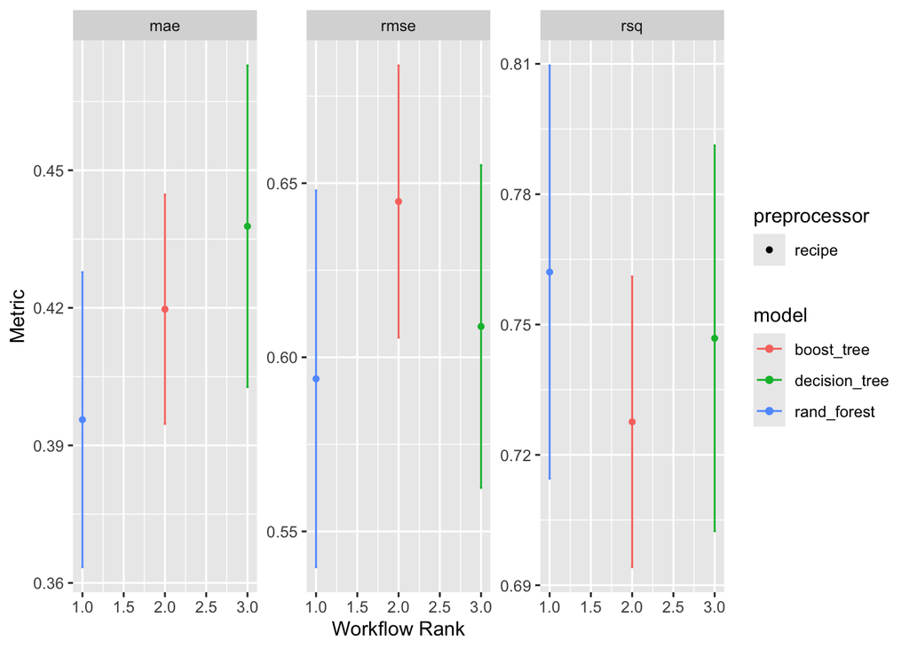

```r
# build resamples
camels_cv <- vfold_cv(camels_train, v = 10)

# build 3 candidate models
xgb_mod <- boost_tree() %>%
  set_engine("xgboost") %>%
  set_mode("regression")

dt_mod <- decision_tree() %>%
  set_engine("rpart") %>%
  set_mode("regression")

rf_mod <- rand_forest() %>%
  set_engine("ranger") %>%
  set_mode("regression")

# test the models
wf <- workflow_set(list(rec), list(boost = xgb_mod,
                                   dt = dt_mod,
                                   ranger = rf_mod)) %>%
  workflow_map(resamples = camels_cv,
               metrics = metric_set(mae, rsq, rmse))

autoplot(wf)
```

```r
rank_results(wf, rank_metric = "rsq", select_best = TRUE)
```

```
# A tibble: 9 × 9
  wflow_id      .config     .metric  mean std_err     n preprocessor model  rank
  <chr>         <chr>       <chr>   <dbl>   <dbl> <int> <chr>        <chr> <int>
1 recipe_ranger Preprocess… mae     0.396  0.0196    10 recipe       rand…     1
2 recipe_ranger Preprocess… rmse    0.594  0.0329    10 recipe       rand…     1
3 recipe_ranger Preprocess… rsq     0.762  0.0289    10 recipe       rand…     1
4 recipe_dt     Preprocess… mae     0.438  0.0213    10 recipe       deci…     2
5 recipe_dt     Preprocess… rmse    0.609  0.0282    10 recipe       deci…     2
6 recipe_dt     Preprocess… rsq     0.747  0.0270    10 recipe       deci…     2
7 recipe_boost  Preprocess… mae     0.420  0.0152    10 recipe       boos…     3
8 recipe_boost  Preprocess… rmse    0.645  0.0238    10 recipe       boos…     3
9 recipe_boost  Preprocess… rsq     0.728  0.0203    10 recipe       boos…     3
```

```r
# model selection
```

*Model Selection Reasoning:* Based on the models chosen and the ranked metrics from the autoplot, the random forest model seems the most fitting due to it having the lowest RMSE, indicating that the model’s predictions are closest to the actual values on average. In addition, from the ranking it is ranked first for mae, rmse, and rsq out of the other metrics.

*Selected Model Description:* The random forest model is a “random forest” type, “regression” mode, and the “ranger” engine. I believe this model is best fit for this problem because of its simplicity combined with high predictive accuracy, making it promising for predicting logQmean. In addition, random forest models are known for their robustness against overfitting.

## Model Tuning

```r
# build a model for your chosen specification
rf_tune <- rand_forest(
  mode = "regression",
  mtry = tune(),
  min_n = tune()) %>%
  set_engine("ranger") %>%
  set_mode("regression")

# create a workflow
rf_grid <- grid_regular(
  mtry(range = c(1,5)),
  min_n(range = c(2, 10)),
  levels = 5
)
rf_grid
```

```
# A tibble: 25 × 2
    mtry min_n
   <int> <int>
 1     1     2
 2     2     2
 3     3     2
 4     4     2
 5     5     2
 6     1     4
 7     2     4
 8     3     4
 9     4     4
10     5     4
# ℹ 15 more rows
```

```r
wf_tune <- workflow() %>%
  add_recipe(rec) %>%
  add_model(rf_tune)
wf_tune
```

```
══ Workflow ════════════════════════════════════════════════════════════════════
Preprocessor: Recipe
Model: rand_forest()

── Preprocessor ────────────────────────────────────────────────────────────────
3 Recipe Steps

• step_log()
• step_interact()
• step_naomit()

── Model ───────────────────────────────────────────────────────────────────────
Random Forest Model Specification (regression)

Main Arguments:
  mtry = tune()
  min_n = tune()

Computational engine: ranger
```

```r
rf_tune_results <- wf_tune %>%
  tune_grid(
    resamples = camels_cv,
    grid = rf_grid
  )
```

```
→ A | warning: 4 columns were requested but there were 3 predictors in the data. 3 will be used.
```

```
There were issues with some computations   A: x1
```

```
→ B | warning: 5 columns were requested but there were 3 predictors in the data. 3 will be used.
```

[output not shown]

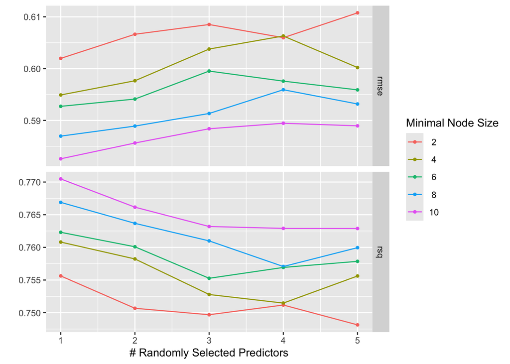

```r
autoplot(rf_tune_results)
```

```r
# define the search space/dials
dials <- extract_parameter_set_dials(wf_tune)
dials <- update(dials, mtry = mtry(range = c(1, 10)))
dials <- update(dials, min_n = min_n(range = c(2, 15)))
my_grid <- grid_space_filling(dials, size = 25)
dials
```

```
Collection of 2 parameters for tuning

 identifier  type    object
       mtry  mtry nparam[+]
      min_n min_n nparam[+]
```

```r
dials <- extract_parameter_set_dials(wf_tune)
dials
```

```
Collection of 2 parameters for tuning

 identifier  type    object
       mtry  mtry nparam[?]
      min_n min_n nparam[+]

Model parameters needing finalization:
   # Randomly Selected Predictors ('mtry')

See `?dials::finalize` or `?dials::update.parameters` for more information.
```

```r
dials$object
```

```
[[1]]
# Randomly Selected Predictors (quantitative)
Range: [1, ?]

[[2]]
Minimal Node Size (quantitative)
Range: [2, 40]
```

```r
dials <- extract_parameter_set_dials(wf_tune)
dials <- finalize(dials, camels_train)
my.grid <- grid_space_filling(dials, size = 25)
my.grid
```

```
# A tibble: 25 × 2
    mtry min_n
   <int> <int>
 1     1    24
 2     3    13
 3     5    33
 4     8     5
 5    10    19
 6    13    27
 7    15    36
 8    17    11
 9    20     3
10    22    21
# ℹ 15 more rows
```

```r
# tune the model
model_params <-  tune_grid(
    wf_tune,
    resamples = camels_cv,
    grid = my.grid,
    metrics = metric_set(rmse, rsq, mae),
    control = control_grid(save_pred = TRUE)
  )
```

[output not shown]

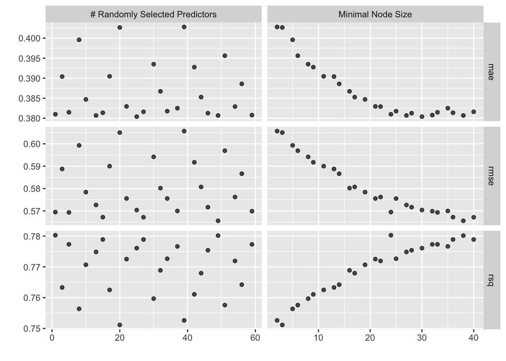

```r
autoplot(model_params)
```

*Model Tuning Description:* From the plot of the model tuning, the first 2 rows show that as minimal node size increases, mae and rmse decreases. In the third row, as minimal node size increases, rsq also increases, indicating a positive relationship. The similarity between mae and rmse with zero outliers indicates that the random forest model was a good choice due to consistency with little to no outliers.

```r
# check the skill of the tuned model
  # collect_metrics
model_params %>% collect_metrics()
```

```
# A tibble: 75 × 8
    mtry min_n .metric .estimator  mean     n std_err .config
   <int> <int> <chr>   <chr>      <dbl> <int>   <dbl> <chr>
 1     1    24 mae     standard   0.381    10  0.0177 Preprocessor1_Model01
 2     1    24 rmse    standard   0.569    10  0.0292 Preprocessor1_Model01
 3     1    24 rsq     standard   0.780    10  0.0250 Preprocessor1_Model01
 4     3    13 mae     standard   0.390    10  0.0195 Preprocessor1_Model02
 5     3    13 rmse    standard   0.589    10  0.0325 Preprocessor1_Model02
 6     3    13 rsq     standard   0.763    10  0.0287 Preprocessor1_Model02
 7     5    33 mae     standard   0.381    10  0.0177 Preprocessor1_Model03
 8     5    33 rmse    standard   0.569    10  0.0288 Preprocessor1_Model03
 9     5    33 rsq     standard   0.777    10  0.0264 Preprocessor1_Model03
10     8     5 mae     standard   0.400    10  0.0202 Preprocessor1_Model04
# ℹ 65 more rows
```

*Collect_Metrics Description:* From using collect_metrics to check the skill of the final tuned model, there is stable performance across the 25 tuning combinations. When gathering the average of rmse, mae, and rsq, it is very close to each individual mean, indicating that the forest performs well with the choices of the hyperparameter.

```r
  # show_best
show_best(model_params, metric = "mae")
```

```
# A tibble: 5 × 8
   mtry min_n .metric .estimator  mean     n std_err .config
  <int> <int> <chr>   <chr>      <dbl> <int>   <dbl> <chr>
1    25    30 mae     standard   0.380    10  0.0184 Preprocessor1_Model11
2    49    38 mae     standard   0.381    10  0.0175 Preprocessor1_Model21
3    13    27 mae     standard   0.381    10  0.0184 Preprocessor1_Model06
4    59    32 mae     standard   0.381    10  0.0176 Preprocessor1_Model25
5     1    24 mae     standard   0.381    10  0.0177 Preprocessor1_Model01
```

```r
  # select_best
hp_best <- select_best(model_params, metric = "mae")

  # finalize your model
final_wf <- finalize_workflow(wf_tune, hp_best)
```

## Final Model Verification

```r
# use last_fit to fit the finalized workflow to the original split
final_fit <- last_fit(final_wf, camels_split)
```

```
→ A | warning: 25 columns were requested but there were 3 predictors in the data. 3 will be used.
```

```r
# use collect_metrics to check the performance of the final model on the TEST data
final_metrics <- collect_metrics(final_fit)
final_metrics
```

```
# A tibble: 2 × 4
  .metric .estimator .estimate .config
  <chr>   <chr>          <dbl> <chr>
1 rmse    standard       0.616 Preprocessor1_Model1
2 rsq     standard       0.796 Preprocessor1_Model1
```

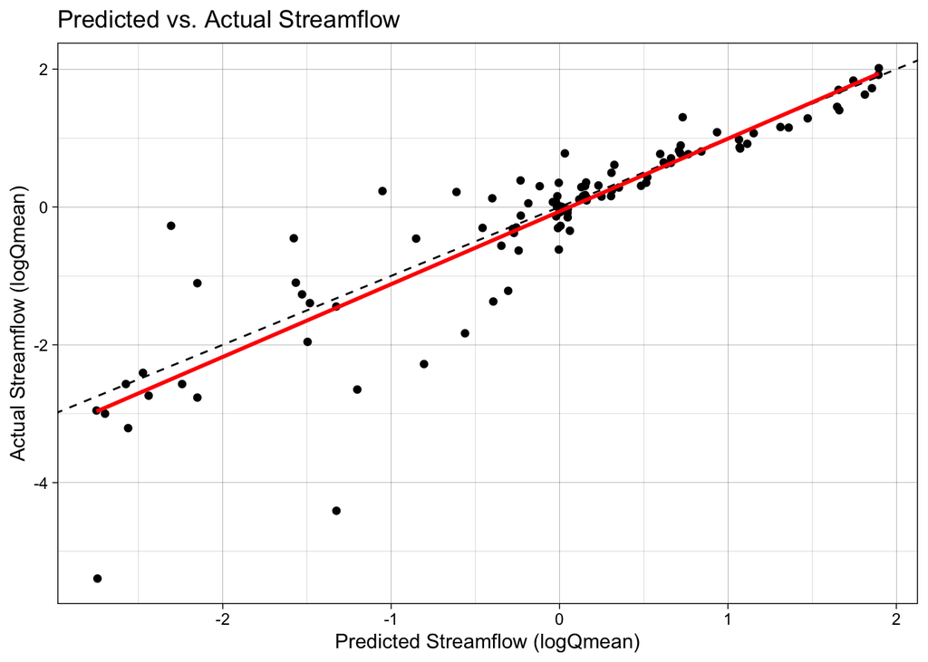

```r
# use collect_predictions to check the predictions of the final model on the test data
final_pred <- collect_predictions(final_fit)

ggplot(final_pred, aes(x = .pred, y = logQmean)) +
  geom_point() +
  scale_color_viridis_c() +
  geom_abline(slope = 1, intercept = 0, linetype = "dashed", color = "black") +
  geom_smooth(method = "lm", color = "red", se = FALSE) +
  theme_linedraw() +
  labs(title = "Predicted vs. Actual Streamflow",
       x = "Predicted Streamflow (logQmean)",
       y = "Actual Streamflow (logQmean)")
```

## Building a Map!

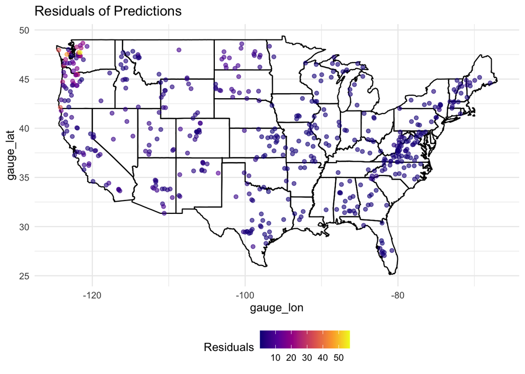

```r
# pass the final fit to the augment function to make predictions on the full, cleaned data
final_model_full <- fit(final_wf, data = camels)
predictions <- augment(final_model_full, new_data = camels)

# use mutate to calculate the residuals of the predictions (predicted - actual)^2
residuals <- predictions %>%
  mutate(residuals = (.pred - q_mean)^2)

# map predictions
pred_map <- ggplot(predictions, aes(x = gauge_lon, y = gauge_lat, color = .pred)) + borders("state", colour = "black", fill = NA) +
  geom_point(alpha = 0.6) +
  scale_color_viridis_c(option = "C") +
  labs(title = "Predicted Streamflow (q_mean)", color = "Predicted Value") +
  theme_minimal() +
  theme(legend.position = "bottom")

# map residuals
resid_map <- ggplot(residuals, aes(x = gauge_lon, y = gauge_lat, color = residuals)) + borders("state", colour = "black", fill = NA) +
  geom_point(alpha = 0.6) +
  scale_color_viridis_c(option = "C") +
  labs(title = "Residuals of Predictions ", color = "Residuals") +
  theme_minimal() +
  theme(legend.position = "bottom")

print(resid_map)
```

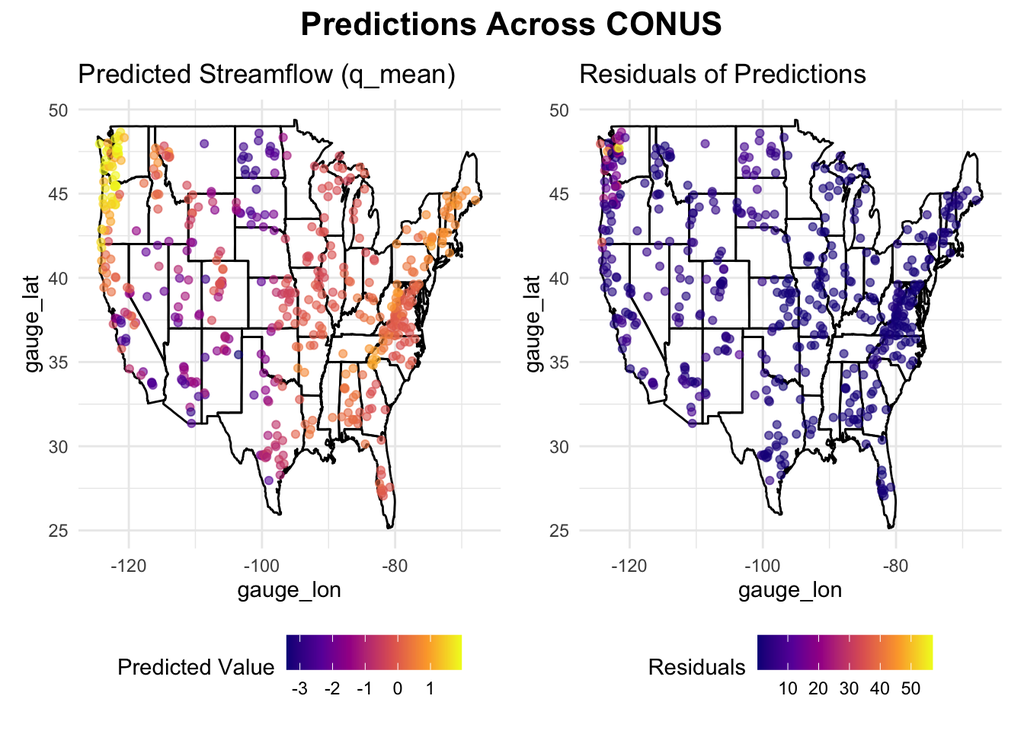

```r
# combine the two maps into one figure
combined_map <- pred_map + resid_map +
  plot_annotation(
    title = "Predictions Across CONUS",
    theme = theme(
      plot.title = element_text(size = 16, face = "bold", hjust = 0.5)
    )
  )
print(combined_map)
```